# BCLiquor_Regressions

Rock Chi

Thursday, September 24, 2015

Just some of the regressions and CART as shown in the presentation. Rather than only having R code, a full html document with code, plot should be hopefully more helpful.

The overall focus of these quick models were for interpretability of variable importance and correlation to price over predication accuracy.

```r
liquor <- read.csv("C:/Users/KaLok/Desktop/BC_Liquor_Store_Product_Price_List.csv")
liquor$LogPrice <- log(liquor$CURRENT_DISPLAY_PRICE)
wine <- subset(liquor, PRODUCT_SUB_CLASS_NAME == "TABLE WINE")
```

First regression using LogPrice as target. Predictors include Minor Class Names (Red, White, Rose) and Wine Country Origin

```r
lm1 <- lm(LogPrice~PRODUCT_MINOR_CLASS_NAME+PRODUCT_COUNTRY_ORIGIN_NAME+PRODUCT_ALCOHOL_PERCENT, data=wine)
summary(lm1)
```

```
##
## Call:
## lm(formula = LogPrice ~ PRODUCT_MINOR_CLASS_NAME + PRODUCT_COUNTRY_ORIGIN_NAME +
##     PRODUCT_ALCOHOL_PERCENT, data = wine)
##
## Residuals:
##     Min      1Q  Median      3Q     Max
## -2.3678 -0.5480 -0.1183  0.4272  5.2883
##
## Coefficients:
##                                                     Estimate Std. Error
## (Intercept)                                          1.11437    0.50687
## PRODUCT_MINOR_CLASS_NAMEICE WINE WHITE               0.33328    0.50127
## PRODUCT_MINOR_CLASS_NAMETABLE WINE RED              -0.64238    0.45893
## PRODUCT_MINOR_CLASS_NAMETABLE WINE ROSE             -1.35103    0.47117
## PRODUCT_MINOR_CLASS_NAMETABLE WINE WHITE            -0.91457    0.45869
## PRODUCT_COUNTRY_ORIGIN_NAMEAUSTRALIA                 0.19345    0.09121
## PRODUCT_COUNTRY_ORIGIN_NAMEAUSTRIA                   0.78365    0.26638
## PRODUCT_COUNTRY_ORIGIN_NAMEBULGARIA                 -0.09286    0.53278
## PRODUCT_COUNTRY_ORIGIN_NAMECANADA                    0.36130    0.08881
## PRODUCT_COUNTRY_ORIGIN_NAMECHILE                     0.15702    0.10533
## PRODUCT_COUNTRY_ORIGIN_NAMECROATIA                   0.97033    0.91639
## PRODUCT_COUNTRY_ORIGIN_NAMEFRANCE                    1.71503    0.08207
## PRODUCT_COUNTRY_ORIGIN_NAMEGEORGIA                   0.02237    0.53291
## PRODUCT_COUNTRY_ORIGIN_NAMEGERMANY                   1.14750    0.12946
## PRODUCT_COUNTRY_ORIGIN_NAMEGREECE                    0.33712    0.26585
## PRODUCT_COUNTRY_ORIGIN_NAMEHUNGARY                   0.49548    0.26633
## PRODUCT_COUNTRY_ORIGIN_NAMEINDIA                     0.23567    0.91699
## PRODUCT_COUNTRY_ORIGIN_NAMEISRAEL                    0.25718    0.25608
## PRODUCT_COUNTRY_ORIGIN_NAMEITALY                     0.89539    0.08758
## PRODUCT_COUNTRY_ORIGIN_NAMELEBANON                   1.24526    0.91643
## PRODUCT_COUNTRY_ORIGIN_NAMEMONTENEGRO               -0.25143    0.91643
## PRODUCT_COUNTRY_ORIGIN_NAMEMOROCCO                   0.55374    0.91635
## PRODUCT_COUNTRY_ORIGIN_NAMENEW ZEALAND               0.41524    0.12991
## PRODUCT_COUNTRY_ORIGIN_NAMEPORTUGAL                  0.38644    0.14400
## PRODUCT_COUNTRY_ORIGIN_NAMESOUTH AFRICA              0.07648    0.12001
## PRODUCT_COUNTRY_ORIGIN_NAMESPAIN                     0.36632    0.10820
## PRODUCT_COUNTRY_ORIGIN_NAMEUNITED STATES OF AMERICA  0.55152    0.08830
## PRODUCT_ALCOHOL_PERCENT                              0.18284    0.01573
##                                                     t value Pr(>|t|)
```

[output cut: 20 more lines]

```
## PRODUCT_COUNTRY_ORIGIN_NAMEMONTENEGRO                -0.274 0.783828
## PRODUCT_COUNTRY_ORIGIN_NAMEMOROCCO                    0.604 0.545686
## PRODUCT_COUNTRY_ORIGIN_NAMENEW ZEALAND                3.196 0.001404 **
## PRODUCT_COUNTRY_ORIGIN_NAMEPORTUGAL                   2.684 0.007313 **
## PRODUCT_COUNTRY_ORIGIN_NAMESOUTH AFRICA               0.637 0.523973
## PRODUCT_COUNTRY_ORIGIN_NAMESPAIN                      3.385 0.000718 ***
## PRODUCT_COUNTRY_ORIGIN_NAMEUNITED STATES OF AMERICA   6.246 4.67e-10 ***
## PRODUCT_ALCOHOL_PERCENT                              11.624  < 2e-16 ***
## ---
## Signif. codes:  0 '***' 0.001 '**' 0.01 '*' 0.05 '.' 0.1 ' ' 1
##
## Residual standard error: 0.9131 on 3746 degrees of freedom
##   (1 observation deleted due to missingness)
## Multiple R-squared:  0.3608, Adjusted R-squared:  0.3562
## F-statistic:  78.3 on 27 and 3746 DF,  p-value: < 2.2e-16
```

Second regression. I added in Sweetness Code into this regression. Something to note that I had realized in retrospective is that Sweetness Code is a categorical. Liquor of certain ranges are grouped together. However in the regression model, the variable was treated as a continuous variable!

```r
wine1 <- subset(wine, SWEETNESS_CODE != "NA")
lm2 <- lm(LogPrice~SWEETNESS_CODE+PRODUCT_MINOR_CLASS_NAME+PRODUCT_COUNTRY_ORIGIN_NAME+PRODUCT_ALCOHOL_PERCENT, data=wine)
summary(lm2)
```

```
##
## Call:
## lm(formula = LogPrice ~ SWEETNESS_CODE + PRODUCT_MINOR_CLASS_NAME +
##     PRODUCT_COUNTRY_ORIGIN_NAME + PRODUCT_ALCOHOL_PERCENT, data = wine)
##
## Residuals:
##     Min      1Q  Median      3Q     Max
## -2.3130 -0.5435 -0.1271  0.4188  5.3431
##
## Coefficients:
##                                                     Estimate Std. Error
## (Intercept)                                          0.47097    0.52376
## SWEETNESS_CODE                                       0.05282    0.01254
## PRODUCT_MINOR_CLASS_NAMEICE WINE WHITE               0.33166    0.49579
## PRODUCT_MINOR_CLASS_NAMETABLE WINE RED              -0.16382    0.46790
## PRODUCT_MINOR_CLASS_NAMETABLE WINE ROSE             -0.88290    0.47882
## PRODUCT_MINOR_CLASS_NAMETABLE WINE WHITE            -0.45473    0.46632
## PRODUCT_COUNTRY_ORIGIN_NAMEAUSTRALIA                 0.17443    0.09045
## PRODUCT_COUNTRY_ORIGIN_NAMEAUSTRIA                   0.81330    0.26360
## PRODUCT_COUNTRY_ORIGIN_NAMEBULGARIA                 -0.08488    0.52694
## PRODUCT_COUNTRY_ORIGIN_NAMECANADA                    0.36517    0.08790
## PRODUCT_COUNTRY_ORIGIN_NAMECHILE                     0.16222    0.10419
## PRODUCT_COUNTRY_ORIGIN_NAMECROATIA                   0.96874    0.90635
## PRODUCT_COUNTRY_ORIGIN_NAMEFRANCE                    1.67579    0.08148
## PRODUCT_COUNTRY_ORIGIN_NAMEGEORGIA                  -0.02580    0.52719
## PRODUCT_COUNTRY_ORIGIN_NAMEGERMANY                   1.09015    0.12877
## PRODUCT_COUNTRY_ORIGIN_NAMEGREECE                    0.36748    0.26305
## PRODUCT_COUNTRY_ORIGIN_NAMEHUNGARY                   0.34502    0.26577
## PRODUCT_COUNTRY_ORIGIN_NAMEINDIA                     0.20572    0.90697
## PRODUCT_COUNTRY_ORIGIN_NAMEISRAEL                    0.26095    0.25328
## PRODUCT_COUNTRY_ORIGIN_NAMEITALY                     0.89915    0.08667
## PRODUCT_COUNTRY_ORIGIN_NAMELEBANON                   1.26089    0.90639
## PRODUCT_COUNTRY_ORIGIN_NAMEMONTENEGRO               -0.23580    0.90639
## PRODUCT_COUNTRY_ORIGIN_NAMEMOROCCO                   0.56363    0.90631
## PRODUCT_COUNTRY_ORIGIN_NAMENEW ZEALAND               0.43706    0.12913
## PRODUCT_COUNTRY_ORIGIN_NAMEPORTUGAL                  0.38778    0.14330
## PRODUCT_COUNTRY_ORIGIN_NAMESOUTH AFRICA              0.06948    0.11907
## PRODUCT_COUNTRY_ORIGIN_NAMESPAIN                     0.37294    0.10703
## PRODUCT_COUNTRY_ORIGIN_NAMEUNITED STATES OF AMERICA  0.55507    0.08734
## PRODUCT_ALCOHOL_PERCENT                              0.19432    0.01585
```

[output cut: 22 more lines]

```
## PRODUCT_COUNTRY_ORIGIN_NAMEMONTENEGRO                -0.260 0.794763
## PRODUCT_COUNTRY_ORIGIN_NAMEMOROCCO                    0.622 0.534048
## PRODUCT_COUNTRY_ORIGIN_NAMENEW ZEALAND                3.385 0.000720 ***
## PRODUCT_COUNTRY_ORIGIN_NAMEPORTUGAL                   2.706 0.006838 **
## PRODUCT_COUNTRY_ORIGIN_NAMESOUTH AFRICA               0.584 0.559572
## PRODUCT_COUNTRY_ORIGIN_NAMESPAIN                      3.484 0.000499 ***
## PRODUCT_COUNTRY_ORIGIN_NAMEUNITED STATES OF AMERICA   6.356 2.33e-10 ***
## PRODUCT_ALCOHOL_PERCENT                              12.262  < 2e-16 ***
## ---
## Signif. codes:  0 '***' 0.001 '**' 0.01 '*' 0.05 '.' 0.1 ' ' 1
##
## Residual standard error: 0.9031 on 3665 degrees of freedom
##   (81 observations deleted due to missingness)
## Multiple R-squared:  0.3546, Adjusted R-squared:  0.3497
## F-statistic: 71.93 on 28 and 3665 DF,  p-value: < 2.2e-16
```

Lastly, I had created a quick CART model. Since the focus is moreso on interpretability rather than accuracy, CART was definitely the superior approach in this case. Furthermore, if accuracy was the goal, CART will prove better especially when Product Name information is included since many Wines did not include information such as Year or Grape Variety.

```r
library(rpart)
```

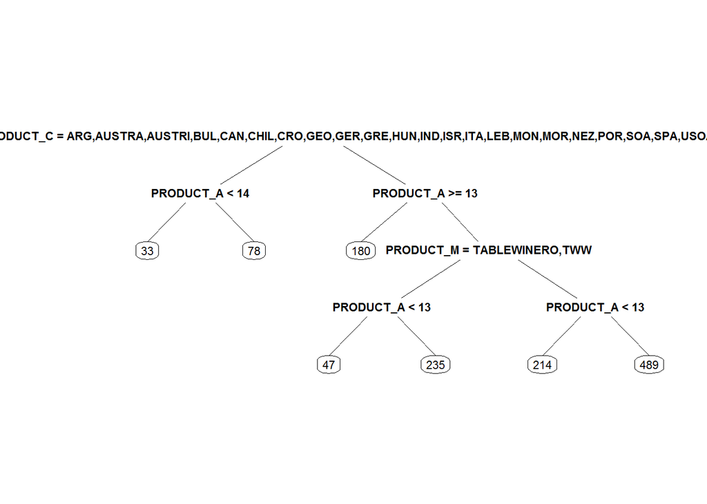

```r
library(rpart.plot)
CART1 <- rpart(CURRENT_DISPLAY_PRICE~SWEETNESS_CODE+PRODUCT_MINOR_CLASS_NAME+PRODUCT_COUNTRY_ORIGIN_NAME+PRODUCT_ALCOHOL_PERCENT, method="anova", data=wine, control=rpart.control(cp=0.001))
prp(CART1)
```